# Classification

Module 6 A3 Week 6

# Introduction

R Programming for Data Science introduced classification through functions in package `class`. Here you will get introduced to a powerful package: `caret`.

*The `caret` package (short for C_lassification A_nd RE_gression T_raining) is a set of functions that attempt to streamline the process for creating predictive models. The package contains tools for*

- data splitting
- preprocessing
- feature selection
- model tuning using resampling
- variable importance estimation

as well as other functionality.

To learn more about package `caret` visit the link in the References section.

To get started, load packages `tidyverse`, `caret`, and `gifski`. Install any packages with code `install.packages("package_name")`.

```r
library(tidyverse)
library(caret)
library(gifski)
```

# Data

We will examine data that are the result of a chemical analysis of wines grown in the same region in Italy but derived from three different cultivars. The analysis determined the quantities of 13 constituents found in each of the three types of wines.

```r
# data url
wineurl <- paste("https://archive.ics.uci.edu/ml/",
                 "machine-learning-databases/wine/wine.data", sep = "")

# read in data and set as tibble
wine <- as_tibble(read.csv(file = wineurl, header = FALSE))

# assign variable names
colnames(wine) <- c("origin", "alcohol", "acid",
                       "ash", "alcalinity", "magnesium",
                       "phenols", "flavanoids", "nonflavanoid",
                       "proanthocyanins","color.int", "hue",
                       "od", "proline")

# change origin to factor
wine <- wine %>%
  mutate(origin = factor(origin))

wine
```

| origin | alcohol | acid | ash | alcalinity | magnesium | phenols | flavanoids | nonflavanoid | proanthocyanins | color.int | hue | od | proline |
| --- | --- | --- | --- | --- | --- | --- | --- | --- | --- | --- | --- | --- | --- |
| 1 | 14.23 | 1.71 | 2.43 | 15.6 | 127 | 2.80 | 3.06 | 0.28 | 2.29 | 5.640000 | 1.040 | 3.92 | 1065 |
| 1 | 13.20 | 1.78 | 2.14 | 11.2 | 100 | 2.65 | 2.76 | 0.26 | 1.28 | 4.380000 | 1.050 | 3.40 | 1050 |
| 1 | 13.16 | 2.36 | 2.67 | 18.6 | 101 | 2.80 | 3.24 | 0.30 | 2.81 | 5.680000 | 1.030 | 3.17 | 1185 |
| 1 | 14.37 | 1.95 | 2.50 | 16.8 | 113 | 3.85 | 3.49 | 0.24 | 2.18 | 7.800000 | 0.860 | 3.45 | 1480 |
| 1 | 13.24 | 2.59 | 2.87 | 21.0 | 118 | 2.80 | 2.69 | 0.39 | 1.82 | 4.320000 | 1.040 | 2.93 | 735 |
| 1 | 14.20 | 1.76 | 2.45 | 15.2 | 112 | 3.27 | 3.39 | 0.34 | 1.97 | 6.750000 | 1.050 | 2.85 | 1450 |
| 1 | 14.39 | 1.87 | 2.45 | 14.6 | 96 | 2.50 | 2.52 | 0.30 | 1.98 | 5.250000 | 1.020 | 3.58 | 1290 |
| 1 | 14.06 | 2.15 | 2.61 | 17.6 | 121 | 2.60 | 2.51 | 0.31 | 1.25 | 5.050000 | 1.060 | 3.58 | 1295 |
| 1 | 14.83 | 1.64 | 2.17 | 14.0 | 97 | 2.80 | 2.98 | 0.29 | 1.98 | 5.200000 | 1.080 | 2.85 | 1045 |
| 1 | 13.86 | 1.35 | 2.27 | 16.0 | 98 | 2.98 | 3.15 | 0.22 | 1.85 | 7.220000 | 1.010 | 3.55 | 1045 |

[output cut: 168 more lines]

**Our goal is to apply the K-NN algorithm and evaluate its prediction accuracy in using the 13 wine features to predict the wine’s origin.**

# Exploratory data analysis

Let’s examine how the features are related to `origin`.

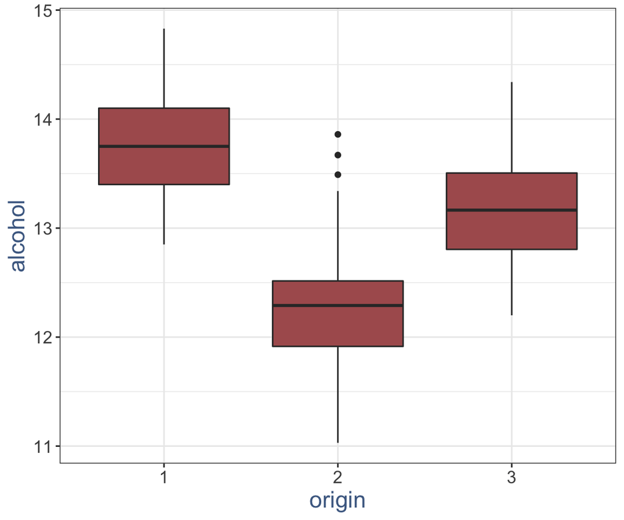

```r
for (i in names(wine)[-1]){
  print({
    wine %>%
      #select(origin, i) %>%
      ggplot(mapping = aes(x = origin, y = get(i))) +
      geom_boxplot(fill = "#AD5D5D") +
      labs(x = "origin", y = i) +
      theme_custom()
  })
}
```

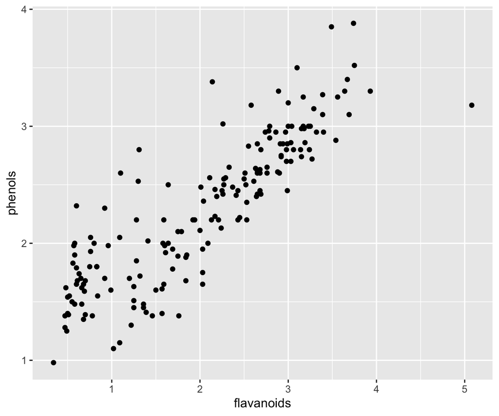

```r
ggplot(wine, aes(x = flavanoids, y = phenols)) + geom_point()
```

# Preprocessing I

Before we train our classifier it is important to examine the features of our data. The results of this analysis may require further preprocessing and give us insight into what distance metric to use for K-NN.

1. How many wine origins exist for each wine? *Hint: `dplyr::count()`*

```r
wine %>%
  dplyr::count("origin")
```

| "origin" | n |
| --- | --- |
| origin | 178 |

2. Are there any `NA` values in the data?

```r
wine[is.na(wine)]
```

```
<unspecified> [0]
```

3. What types of variables are the 13 features? Are they all numeric continuous?

```r
for (i in wine){
  print(typeof(i))
}
```

```
[1] "integer"
[1] "double"
[1] "double"
[1] "double"
[1] "double"
[1] "integer"
[1] "double"
[1] "double"
[1] "double"
[1] "double"
[1] "double"
[1] "double"
[1] "double"
[1] "integer"
```

```r
#all numeric
```

# Data splitting

Next, we split the 178 rows of `wine` into a training dataset and a testing dataset. We train our classifier with the training data set and evaluate the prediction accuracy with the testing dataset.

The function `createDataPartition()` from package `caret` can be used to create balanced splits of the data. Thus, the ratio of outcomes will be preserved in the training and testing datasets. This is important.

Function `createDataPartition(y, p , list = TRUE)` has main arguments:

- `y`: a vector of your outcomes, `origin` from `wine`
- `p`: proportion of overall data that goes to trainning, typically use between 0.70 and 0.80
- `list`: should the results be in a list? Generally, we will set this to `FALSE`.

The result of function `createDataPartition()` is a list or matrix of row indices that correspond to the training data.

1. Use function `createDataPartition()` to get the row indices that will correspond to the trainning dataset. Set `list = FALSE`, and choose a split percentage of 70%. Save the result as an object `train.index`.

```r
train.index = createDataPartition(y = wine$origin, p = 0.7, list = FALSE)
```

2. Use `train.index` to subset the rows of `wine` to create your training dataset. Save the result as an object named `wine.train`. *Hint: `dplyr::slice()`*

```r
wine.train = dplyr::slice(wine, n = train.index)
```

3. Use the other indices to subset the rows of `wine` to create your testing dataset. Save the result as an object named `wine.test`. *Hint: `dplyr::slice()`, use a minus sign*

```r
wine.test = dplyr::slice(wine, n = -train.index)
```

Max Kuhn details other data splitting functionality at https://topepo.github.io/caret/.

# Preprocessing II

K-NN operates on the basis of a distance metric. Therefore, it is helpful if all our features are standardized. Function `preProcess()` from package `caret` will help do this correctly and efficiently. The function performs preprocessing transformations (centering, scaling etc.) that can be estimated from the training data and applied to any dataset with the same variables.

Function `preProcess(x, method = c("center", "scale"))` has main arguments:

- `x`: a matrix or data frame, in this case `wine`
- `method`: type of processing to be done, to standardize we want to center and scale each feature

1. Input `wine.train` into function `preProcess()`, and choose methods center and scale. Save the result as an object named `train.proc`.

```r
train.proc = preProcess(wine.train,method = c("center", "scale") )
```

2. Display `train.proc$mean` and `train.proc$std` to see the mean and standard deviation of each feature.

```r
train.proc$mean
```

```
        alcohol            acid             ash      alcalinity       magnesium
     12.9477778       2.3604762       2.3817460      19.6365079      99.5793651
        phenols      flavanoids    nonflavanoid proanthocyanins       color.int
      2.2813492       2.0264286       0.3616667       1.5842063       5.0624603
            hue              od         proline
      0.9491746       2.5919048     754.5634921
```

```r
train.proc$std
```

```
        alcohol            acid             ash      alcalinity       magnesium
      0.8081365       1.1198370       0.2714585       3.4392930      14.0873578
        phenols      flavanoids    nonflavanoid proanthocyanins       color.int
      0.6149112       1.0026026       0.1258237       0.5886219       2.3188724
            hue              od         proline
      0.2280851       0.7248059     327.7786935
```

When and how you standardize and when you split the data is one of the most common mistakes. See item 3 in References for a nice explanation on the correct procedure.

# K-NN

The `caret` `train()` function lets us train different algorithms using similar syntax. We can use function `predict()` to obtain predictions.

Function `train(form, method, data)` has the main arguments we need:

The result of function `train()` is a list. Type `?train` in your console to look at the “Value” section of the help.

1. Use `train()` to train the K-NN classifier. Save the result as an object named `train.knn`.

```r
train.knn = train(form = origin ~ ., data = train.transformed, method = 'knn'  )
```

```
Error in eval(expr, p): object 'train.transformed' not found
```

# Cross validation

When an algorithm includes a tuning parameter, function `train()` automatically uses cross validation to decide among a few default values. Recall that K-NN has one tuning parameter, $k$.

By default, the cross validation is performed by taking 25 bootstrap samples comprised of 25% of the observations. Default is to try $k = 5, 7, 9$. We can change these $k$ values using the `tuneGrid` parameter in function `train()`. The grid of values must be supplied by a data frame with the parameter names as columns.

```r
train.knn$bestTune
```

```
Error in eval(expr, envir, enclos): object 'train.knn' not found
```

```r
wine[3]
```

| acid |
| --- |
| 1.71 |
| 1.78 |
| 2.36 |
| 1.95 |
| 2.59 |
| 1.76 |
| 1.87 |
| 2.15 |
| 1.64 |
| 1.35 |

[output cut: 168 more lines]

```r
#maximized acid

train.knn.big.grid$bestTune
```

```
Error in eval(expr, envir, enclos): object 'train.knn.big.grid' not found
```

```r
wine[14]
```

| proline |
| --- |
| 1065 |
| 1050 |
| 1185 |
| 1480 |
| 735 |
| 1450 |
| 1290 |
| 1295 |
| 1045 |
| 1045 |

[output cut: 168 more lines]

```r
#proline
```

```r
y.hat <- predict(train.knn.big.grid, test.transformed)
```

```
Error in predict(train.knn.big.grid, test.transformed): object 'train.knn.big.grid' not found
```

```r
confusionMatrix(data = y.hat, reference = test.transformed$origin)
```

```
Error in confusionMatrix(data = y.hat, reference = test.transformed$origin): object 'y.hat' not found
```

# References

1. https://topepo.github.io/caret/
2. https://archive.ics.uci.edu/ml/datasets/wine
3. https://sebastianraschka.com/faq/docs/scale-training-test.html